# Data importing and Preprocessing

```python
# importing numpy library for  mathematical or scientific calculation
import numpy as np

# importing pandas library for manipulating and analyzing data
import pandas as pd

# importing seaborn library for making statistical graphics
import seaborn as sns

# importing matplotlib library to create visualizations
import matplotlib.pyplot as plt
```

```python
# importing all given csv file to dataframe

df = pd.read_csv('sydney_rain prediction.csv')
```

```python
# To understand the data given we use df.head() which shows only first 5 rows by default

df.head()
```

|  | Date | Location | MinTemp | MaxTemp | Rainfall | Evaporation | Sunshine | Humidity9am | Humidity3pm | Pressure9am | Pressure3pm | Cloud9am | Cloud3pm | Temp9am | Temp3pm | RainToday | RainTomorrow |
| --- | --- | --- | --- | --- | --- | --- | --- | --- | --- | --- | --- | --- | --- | --- | --- | --- | --- |
| 0 | 01-02-2008 | Sydney | 19.5 | 22.4 | 15.6 | 6.2 | 0.0 | 92.0 | 84.0 | 1017.6 | 1017.4 | 8.0 | 8.0 | 20.7 | 20.9 | Yes | Yes |
| 1 | 02-02-2008 | Sydney | 19.5 | 25.6 | 6.0 | 3.4 | 2.7 | 83.0 | 73.0 | 1017.9 | 1016.4 | 7.0 | 7.0 | 22.4 | 24.8 | Yes | Yes |
| 2 | 03-02-2008 | Sydney | 21.6 | 24.5 | 6.6 | 2.4 | 0.1 | 88.0 | 86.0 | 1016.7 | 1015.6 | 7.0 | 8.0 | 23.5 | 23.0 | Yes | Yes |
| 3 | 04-02-2008 | Sydney | 20.2 | 22.8 | 18.8 | 2.2 | 0.0 | 83.0 | 90.0 | 1014.2 | 1011.8 | 8.0 | 8.0 | 21.4 | 20.9 | Yes | Yes |
| 4 | 05-02-2008 | Sydney | 19.7 | 25.7 | 77.4 | NaN | 0.0 | 88.0 | 74.0 | 1008.3 | 1004.8 | 8.0 | 8.0 | 22.5 | 25.5 | Yes | Yes |

```python
# df.shape is used to find total number of rows and columns

df.shape
```

```
(3337, 17)
```

```python
# Displaying concise summary of the DataFrame structure

df.info()
```

```
<class 'pandas.core.frame.DataFrame'>
RangeIndex: 3337 entries, 0 to 3336
Data columns (total 17 columns):
 #   Column        Non-Null Count  Dtype
---  ------        --------------  -----
 0   Date          3337 non-null   object
 1   Location      3337 non-null   object
 2   MinTemp       3334 non-null   float64
 3   MaxTemp       3335 non-null   float64
 4   Rainfall      3331 non-null   float64
 5   Evaporation   3286 non-null   float64
 6   Sunshine      3321 non-null   float64
 7   Humidity9am   3323 non-null   float64
 8   Humidity3pm   3324 non-null   float64
 9   Pressure9am   3317 non-null   float64
 10  Pressure3pm   3318 non-null   float64
 11  Cloud9am      2771 non-null   float64
 12  Cloud3pm      2776 non-null   float64
 13  Temp9am       3333 non-null   float64
 14  Temp3pm       3333 non-null   float64
 15  RainToday     3331 non-null   object
 16  RainTomorrow  3337 non-null   object
dtypes: float64(13), object(4)
memory usage: 443.3+ KB
```

```python
df.Location
```

```
0       Sydney
1       Sydney
2       Sydney
3       Sydney
4       Sydney
         ...
3332    Sydney
3333    Sydney
3334    Sydney
3335    Sydney
3336    Sydney
Name: Location, Length: 3337, dtype: object
```

```python
df.describe()
```

|  | MinTemp | MaxTemp | Rainfall | Evaporation | Sunshine | Humidity9am | Humidity3pm | Pressure9am | Pressure3pm | Cloud9am | Cloud3pm | Temp9am | Temp3pm |
| --- | --- | --- | --- | --- | --- | --- | --- | --- | --- | --- | --- | --- | --- |
| count | 3334.000000 | 3335.000000 | 3331.000000 | 3286.000000 | 3321.000000 | 3323.000000 | 3324.000000 | 3317.000000 | 3318.000000 | 2771.000000 | 2776.000000 | 3333.000000 | 3333.000000 |
| mean | 14.865057 | 23.002339 | 3.330231 | 5.187432 | 7.179374 | 68.229010 | 54.699158 | 1018.346156 | 1016.018774 | 4.181523 | 4.218660 | 17.819742 | 21.533333 |
| std | 4.553641 | 4.494638 | 9.895172 | 2.777407 | 3.810886 | 15.085355 | 16.293530 | 7.021571 | 7.032211 | 2.749578 | 2.641885 | 4.897177 | 4.303737 |
| min | 4.300000 | 11.700000 | 0.000000 | 0.000000 | 0.000000 | 19.000000 | 10.000000 | 986.700000 | 989.800000 | 0.000000 | 0.000000 | 6.400000 | 10.200000 |
| 25% | 11.000000 | 19.600000 | 0.000000 | 3.200000 | 4.300000 | 58.000000 | 44.000000 | 1013.700000 | 1011.300000 | 1.000000 | 1.000000 | 13.800000 | 18.400000 |
| 50% | 14.900000 | 22.800000 | 0.000000 | 4.800000 | 8.300000 | 69.000000 | 56.000000 | 1018.600000 | 1016.300000 | 5.000000 | 4.000000 | 18.200000 | 21.300000 |
| 75% | 18.700000 | 26.000000 | 1.400000 | 7.000000 | 10.200000 | 80.000000 | 65.000000 | 1023.100000 | 1020.800000 | 7.000000 | 7.000000 | 21.700000 | 24.500000 |
| max | 27.600000 | 45.800000 | 119.400000 | 18.400000 | 13.600000 | 100.000000 | 99.000000 | 1039.000000 | 1036.700000 | 9.000000 | 8.000000 | 36.500000 | 44.700000 |

```python
df.Date
```

```
0       01-02-2008
1       02-02-2008
2       03-02-2008
3       04-02-2008
4       05-02-2008
           ...
3332    21-06-2017
3333    22-06-2017
3334    23-06-2017
3335    24-06-2017
3336    25-06-2017
Name: Date, Length: 3337, dtype: object
```

# Finding Outliers

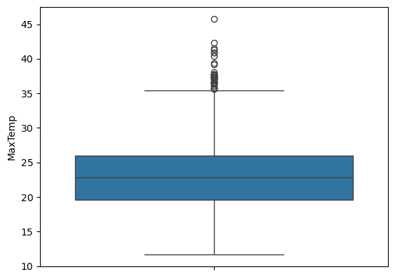

```python
# box plot helps us to find outliers

sns.boxplot(y = 'MaxTemp', data = df)
```

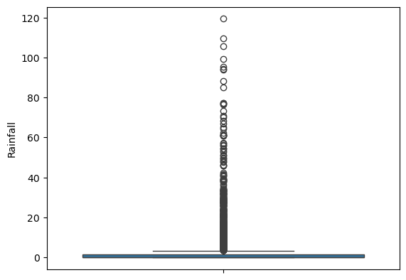

```python
sns.boxplot(y = 'Rainfall', data = df)
```

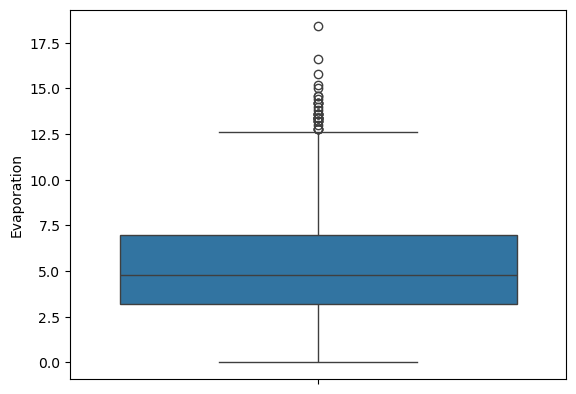

```python
sns.boxplot(y = 'Evaporation', data = df)
```

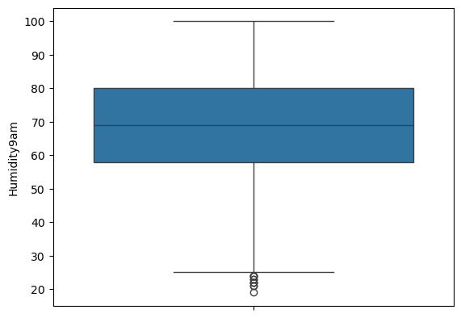

```python
sns.boxplot(y = 'Humidity9am', data = df)
```

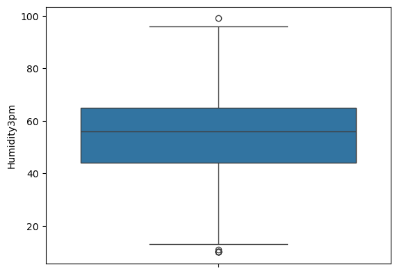

```python
sns.boxplot(y = 'Humidity3pm', data = df)
```

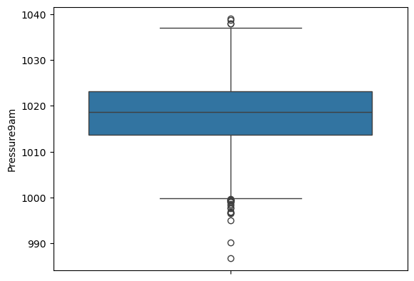

```python
sns.boxplot(y = 'Pressure9am', data = df)
```

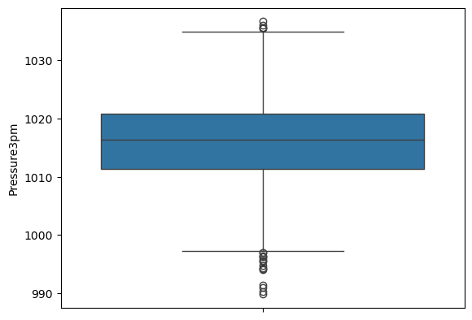

```python
sns.boxplot(y = 'Pressure3pm', data = df)
```

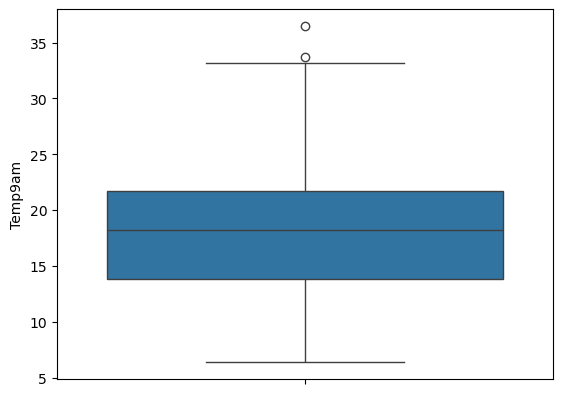

```python
sns.boxplot(y = 'Temp9am', data = df)
```

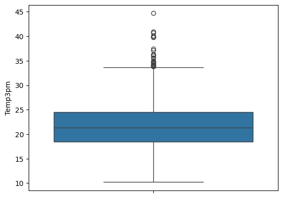

```python
sns.boxplot(y = 'Temp3pm', data = df)
```

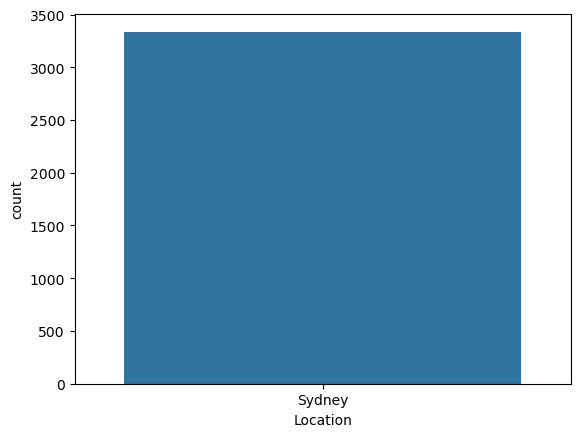

```python
sns.countplot(x = 'Location', data =df)
```

```python
df.info()
```

```
<class 'pandas.core.frame.DataFrame'>
RangeIndex: 3337 entries, 0 to 3336
Data columns (total 17 columns):
 #   Column        Non-Null Count  Dtype
---  ------        --------------  -----
 0   Date          3337 non-null   object
 1   Location      3337 non-null   object
 2   MinTemp       3334 non-null   float64
 3   MaxTemp       3335 non-null   float64
 4   Rainfall      3331 non-null   float64
 5   Evaporation   3286 non-null   float64
 6   Sunshine      3321 non-null   float64
 7   Humidity9am   3323 non-null   float64
 8   Humidity3pm   3324 non-null   float64
 9   Pressure9am   3317 non-null   float64
 10  Pressure3pm   3318 non-null   float64
 11  Cloud9am      2771 non-null   float64
 12  Cloud3pm      2776 non-null   float64
 13  Temp9am       3333 non-null   float64
 14  Temp3pm       3333 non-null   float64
 15  RainToday     3331 non-null   object
 16  RainTomorrow  3337 non-null   object
dtypes: float64(13), object(4)
memory usage: 443.3+ KB
```

# Observations

1)Skewness or outliers present in maxtemp,rainfall,evoperation,humidity(9am and 3pm),pressure(9am and 3pm),temp(9am and 3pm).

2)Missing values are present in all columns except in date,location,raintomorrow.

3)Location column contains only one categorical value so we can delete it.

4)Date column is not usefull so we can delete this column also.

# Outlier handeling

```python
# Calculate the 25th (Q1) and 75th (Q3) percentiles for the 'MaxTemp' column.

Q1 = df['MaxTemp'].quantile(0.25)
Q3 = df['MaxTemp'].quantile(0.75)
```

```python
print(Q1,Q3)
```

```
19.6 26.0
```

```python
IQR = Q3 - Q1
lower_bound = Q1 - 1.5 * IQR
upper_bound = Q3 + 1.5 * IQR
```

```python
df['MaxTemp'] = np.where(df['MaxTemp'] > upper_bound, upper_bound, df['MaxTemp'])
df['MaxTemp'] = np.where(df['MaxTemp'] < lower_bound, lower_bound, df['MaxTemp'])
```

```python
# Calculate the 25th (Q1) and 75th (Q3) percentiles for the 'Evaporation' column.

Q1 = df['Evaporation'].quantile(0.25)
Q3 = df['Evaporation'].quantile(0.75)
```

```python
print(Q1,Q3)
```

```
3.2 7.0
```

```python
IQR = Q3 - Q1
lower_bound = Q1 - 1.5 * IQR
upper_bound = Q3 + 1.5 * IQR
```

```python
df['Evaporation'] = np.where(df['Evaporation'] > upper_bound, upper_bound, df['Evaporation'])
df['Evaporation'] = np.where(df['Evaporation'] < lower_bound, lower_bound, df['Evaporation'])
```

```python
# Calculate the 25th (Q1) and 75th (Q3) percentiles for the 'Humidity9am' column.

Q1 = df['Humidity9am'].quantile(0.25)
Q3 = df['Humidity9am'].quantile(0.75)
```

```python
print(Q1,Q3)
```

```
58.0 80.0
```

```python
IQR = Q3 - Q1
lower_bound = Q1 - 1.5 * IQR
upper_bound = Q3 + 1.5 * IQR
```

```python
df['Humidity9am'] = np.where(df['Humidity9am'] > upper_bound, upper_bound, df['Humidity9am'])
df['Humidity9am'] = np.where(df['Humidity9am'] < lower_bound, lower_bound, df['Humidity9am'])
```

```python
# Calculate the 25th (Q1) and 75th (Q3) percentiles for the 'Humidity3pm' column.

Q1 = df['Humidity3pm'].quantile(0.25)
Q3 = df['Humidity3pm'].quantile(0.75)
```

```python
print(Q1,Q3)
```

```
44.0 65.0
```

```python
IQR = Q3 - Q1
lower_bound = Q1 - 1.5 * IQR
upper_bound = Q3 + 1.5 * IQR
```

```python
df['Humidity3pm'] = np.where(df['Humidity3pm'] > upper_bound, upper_bound, df['Humidity3pm'])
df['Humidity3pm'] = np.where(df['Humidity3pm'] < lower_bound, lower_bound, df['Humidity3pm'])
```

```python
# Calculate the 25th (Q1) and 75th (Q3) percentiles for the 'Pressure9am' column.

Q1 = df['Pressure9am'].quantile(0.25)
Q3 = df['Pressure9am'].quantile(0.75)
```

```python
print(Q1,Q3)
```

```
1013.7 1023.1
```

```python
IQR = Q3 - Q1
lower_bound = Q1 - 1.5 * IQR
upper_bound = Q3 + 1.5 * IQR
```

```python
df['Pressure9am'] = np.where(df['Pressure9am'] > upper_bound, upper_bound, df['Pressure9am'])
df['Pressure9am'] = np.where(df['Pressure9am'] < lower_bound, lower_bound, df['Pressure9am'])
```

```python
# Calculate the 25th (Q1) and 75th (Q3) percentiles for the 'Pressure3pm' column.

Q1 = df['Pressure3pm'].quantile(0.25)
Q3 = df['Pressure3pm'].quantile(0.75)
```

```python
print(Q1,Q3)
```

```
1011.3 1020.8
```

```python
IQR = Q3 - Q1
lower_bound = Q1 - 1.5 * IQR
upper_bound = Q3 + 1.5 * IQR
```

```python
df['Pressure3pm'] = np.where(df['Pressure3pm'] > upper_bound, upper_bound, df['Pressure3pm'])
df['Pressure3pm'] = np.where(df['Pressure3pm'] < lower_bound, lower_bound, df['Pressure3pm'])
```

```python
# Calculate the 25th (Q1) and 75th (Q3) percentiles for the 'Temp9am' column.

Q1 = df['Temp9am'].quantile(0.25)
Q3 = df['Temp9am'].quantile(0.75)
```

```python
print(Q1,Q3)
```

```
13.8 21.7
```

```python
IQR = Q3 - Q1
lower_bound = Q1 - 1.5 * IQR
upper_bound = Q3 + 1.5 * IQR
```

```python
df['Temp9am'] = np.where(df['Temp9am'] > upper_bound, upper_bound, df['Temp9am'])
df['Temp9am'] = np.where(df['Temp9am'] < lower_bound, lower_bound, df['Temp9am'])
```

```python
# Calculate the 25th (Q1) and 75th (Q3) percentiles for the 'Temp3pm' column.

Q1 = df['Temp3pm'].quantile(0.25)
Q3 = df['Temp3pm'].quantile(0.75)
```

```python
print(Q1,Q3)
```

```
18.4 24.5
```

```python
IQR = Q3 - Q1
lower_bound = Q1 - 1.5 * IQR
upper_bound = Q3 + 1.5 * IQR
```

```python
df['Temp3pm'] = np.where(df['Temp3pm'] > upper_bound, upper_bound, df['Temp3pm'])
df['Temp3pm'] = np.where(df['Temp3pm'] < lower_bound, lower_bound, df['Temp3pm'])
```

```python
# Calculate the 25th (Q1) and 75th (Q3) percentiles for the 'Rainfall' column.

Q1 = df['Rainfall'].quantile(0.25)
Q3 = df['Rainfall'].quantile(0.75)
```

```python
print(Q1,Q3)
```

```
0.0 1.4
```

```python
IQR = Q3 - Q1
lower_bound = Q1 - 1.5 * IQR
upper_bound = Q3 + 1.5 * IQR
```

```python
df['Rainfall'] = np.where(df['Rainfall'] > upper_bound, upper_bound, df['Rainfall'])
df['Rainfall'] = np.where(df['Rainfall'] < lower_bound, lower_bound, df['Rainfall'])
```

```python
df.describe()
```

|  | MinTemp | MaxTemp | Rainfall | Evaporation | Sunshine | Humidity9am | Humidity3pm | Pressure9am | Pressure3pm | Cloud9am | Cloud3pm | Temp9am | Temp3pm |
| --- | --- | --- | --- | --- | --- | --- | --- | --- | --- | --- | --- | --- | --- |
| count | 3334.000000 | 3335.000000 | 3331.000000 | 3286.000000 | 3321.000000 | 3323.000000 | 3324.000000 | 3317.000000 | 3318.000000 | 2771.000000 | 2776.000000 | 3333.000000 | 3333.000000 |
| mean | 14.865057 | 22.977181 | 0.864485 | 5.174194 | 7.179374 | 68.238339 | 54.702617 | 1018.358999 | 1016.030513 | 4.181523 | 4.218660 | 17.818812 | 21.510171 |
| std | 4.553641 | 4.410634 | 1.390948 | 2.735794 | 3.810886 | 15.057518 | 16.280316 | 6.972101 | 6.988824 | 2.749578 | 2.641885 | 4.893920 | 4.222308 |
| min | 4.300000 | 11.700000 | 0.000000 | 0.000000 | 0.000000 | 25.000000 | 12.500000 | 999.600000 | 997.050000 | 0.000000 | 0.000000 | 6.400000 | 10.200000 |
| 25% | 11.000000 | 19.600000 | 0.000000 | 3.200000 | 4.300000 | 58.000000 | 44.000000 | 1013.700000 | 1011.300000 | 1.000000 | 1.000000 | 13.800000 | 18.400000 |
| 50% | 14.900000 | 22.800000 | 0.000000 | 4.800000 | 8.300000 | 69.000000 | 56.000000 | 1018.600000 | 1016.300000 | 5.000000 | 4.000000 | 18.200000 | 21.300000 |
| 75% | 18.700000 | 26.000000 | 1.400000 | 7.000000 | 10.200000 | 80.000000 | 65.000000 | 1023.100000 | 1020.800000 | 7.000000 | 7.000000 | 21.700000 | 24.500000 |
| max | 27.600000 | 35.600000 | 3.500000 | 12.700000 | 13.600000 | 100.000000 | 96.500000 | 1037.200000 | 1035.050000 | 9.000000 | 8.000000 | 33.550000 | 33.650000 |

# Deleting useless columns

```python
del df['Location']
```

```python
del df['Date']
```

```python
df.head()
```

|  | MinTemp | MaxTemp | Rainfall | Evaporation | Sunshine | Humidity9am | Humidity3pm | Pressure9am | Pressure3pm | Cloud9am | Cloud3pm | Temp9am | Temp3pm | RainToday | RainTomorrow |
| --- | --- | --- | --- | --- | --- | --- | --- | --- | --- | --- | --- | --- | --- | --- | --- |
| 0 | 19.5 | 22.4 | 3.5 | 6.2 | 0.0 | 92.0 | 84.0 | 1017.6 | 1017.4 | 8.0 | 8.0 | 20.7 | 20.9 | Yes | Yes |
| 1 | 19.5 | 25.6 | 3.5 | 3.4 | 2.7 | 83.0 | 73.0 | 1017.9 | 1016.4 | 7.0 | 7.0 | 22.4 | 24.8 | Yes | Yes |
| 2 | 21.6 | 24.5 | 3.5 | 2.4 | 0.1 | 88.0 | 86.0 | 1016.7 | 1015.6 | 7.0 | 8.0 | 23.5 | 23.0 | Yes | Yes |
| 3 | 20.2 | 22.8 | 3.5 | 2.2 | 0.0 | 83.0 | 90.0 | 1014.2 | 1011.8 | 8.0 | 8.0 | 21.4 | 20.9 | Yes | Yes |
| 4 | 19.7 | 25.7 | 3.5 | NaN | 0.0 | 88.0 | 74.0 | 1008.3 | 1004.8 | 8.0 | 8.0 | 22.5 | 25.5 | Yes | Yes |

# Creating dummy values

```python
# get_dummies() function creates dummy variables from categorical variables

df = pd.get_dummies(df, dtype = int)
```

```python
df.head()
```

|  | MinTemp | MaxTemp | Rainfall | Evaporation | Sunshine | Humidity9am | Humidity3pm | Pressure9am | Pressure3pm | Cloud9am | Cloud3pm | Temp9am | Temp3pm | RainToday_No | RainToday_Yes | RainTomorrow_No | RainTomorrow_Yes |
| --- | --- | --- | --- | --- | --- | --- | --- | --- | --- | --- | --- | --- | --- | --- | --- | --- | --- |
| 0 | 19.5 | 22.4 | 3.5 | 6.2 | 0.0 | 92.0 | 84.0 | 1017.6 | 1017.4 | 8.0 | 8.0 | 20.7 | 20.9 | 0 | 1 | 0 | 1 |
| 1 | 19.5 | 25.6 | 3.5 | 3.4 | 2.7 | 83.0 | 73.0 | 1017.9 | 1016.4 | 7.0 | 7.0 | 22.4 | 24.8 | 0 | 1 | 0 | 1 |
| 2 | 21.6 | 24.5 | 3.5 | 2.4 | 0.1 | 88.0 | 86.0 | 1016.7 | 1015.6 | 7.0 | 8.0 | 23.5 | 23.0 | 0 | 1 | 0 | 1 |
| 3 | 20.2 | 22.8 | 3.5 | 2.2 | 0.0 | 83.0 | 90.0 | 1014.2 | 1011.8 | 8.0 | 8.0 | 21.4 | 20.9 | 0 | 1 | 0 | 1 |
| 4 | 19.7 | 25.7 | 3.5 | NaN | 0.0 | 88.0 | 74.0 | 1008.3 | 1004.8 | 8.0 | 8.0 | 22.5 | 25.5 | 0 | 1 | 0 | 1 |

```python
del df['RainToday_No']
del df['RainTomorrow_No']
```

```python
df.head()
```

|  | MinTemp | MaxTemp | Rainfall | Evaporation | Sunshine | Humidity9am | Humidity3pm | Pressure9am | Pressure3pm | Cloud9am | Cloud3pm | Temp9am | Temp3pm | RainToday_Yes | RainTomorrow_Yes |
| --- | --- | --- | --- | --- | --- | --- | --- | --- | --- | --- | --- | --- | --- | --- | --- |
| 0 | 19.5 | 22.4 | 3.5 | 6.2 | 0.0 | 92.0 | 84.0 | 1017.6 | 1017.4 | 8.0 | 8.0 | 20.7 | 20.9 | 1 | 1 |
| 1 | 19.5 | 25.6 | 3.5 | 3.4 | 2.7 | 83.0 | 73.0 | 1017.9 | 1016.4 | 7.0 | 7.0 | 22.4 | 24.8 | 1 | 1 |
| 2 | 21.6 | 24.5 | 3.5 | 2.4 | 0.1 | 88.0 | 86.0 | 1016.7 | 1015.6 | 7.0 | 8.0 | 23.5 | 23.0 | 1 | 1 |
| 3 | 20.2 | 22.8 | 3.5 | 2.2 | 0.0 | 83.0 | 90.0 | 1014.2 | 1011.8 | 8.0 | 8.0 | 21.4 | 20.9 | 1 | 1 |
| 4 | 19.7 | 25.7 | 3.5 | NaN | 0.0 | 88.0 | 74.0 | 1008.3 | 1004.8 | 8.0 | 8.0 | 22.5 | 25.5 | 1 | 1 |

```python
df.describe()
```

|  | MinTemp | MaxTemp | Rainfall | Evaporation | Sunshine | Humidity9am | Humidity3pm | Pressure9am | Pressure3pm | Cloud9am | Cloud3pm | Temp9am | Temp3pm | RainToday_Yes | RainTomorrow_Yes |
| --- | --- | --- | --- | --- | --- | --- | --- | --- | --- | --- | --- | --- | --- | --- | --- |
| count | 3334.000000 | 3335.000000 | 3331.000000 | 3286.000000 | 3321.000000 | 3323.000000 | 3324.000000 | 3317.000000 | 3318.000000 | 2771.000000 | 2776.000000 | 3333.000000 | 3333.000000 | 3337.000000 | 3337.000000 |
| mean | 14.865057 | 22.977181 | 0.864485 | 5.174194 | 7.179374 | 68.238339 | 54.702617 | 1018.358999 | 1016.030513 | 4.181523 | 4.218660 | 17.818812 | 21.510171 | 0.259515 | 0.259215 |
| std | 4.553641 | 4.410634 | 1.390948 | 2.735794 | 3.810886 | 15.057518 | 16.280316 | 6.972101 | 6.988824 | 2.749578 | 2.641885 | 4.893920 | 4.222308 | 0.438434 | 0.438269 |
| min | 4.300000 | 11.700000 | 0.000000 | 0.000000 | 0.000000 | 25.000000 | 12.500000 | 999.600000 | 997.050000 | 0.000000 | 0.000000 | 6.400000 | 10.200000 | 0.000000 | 0.000000 |
| 25% | 11.000000 | 19.600000 | 0.000000 | 3.200000 | 4.300000 | 58.000000 | 44.000000 | 1013.700000 | 1011.300000 | 1.000000 | 1.000000 | 13.800000 | 18.400000 | 0.000000 | 0.000000 |
| 50% | 14.900000 | 22.800000 | 0.000000 | 4.800000 | 8.300000 | 69.000000 | 56.000000 | 1018.600000 | 1016.300000 | 5.000000 | 4.000000 | 18.200000 | 21.300000 | 0.000000 | 0.000000 |
| 75% | 18.700000 | 26.000000 | 1.400000 | 7.000000 | 10.200000 | 80.000000 | 65.000000 | 1023.100000 | 1020.800000 | 7.000000 | 7.000000 | 21.700000 | 24.500000 | 1.000000 | 1.000000 |
| max | 27.600000 | 35.600000 | 3.500000 | 12.700000 | 13.600000 | 100.000000 | 96.500000 | 1037.200000 | 1035.050000 | 9.000000 | 8.000000 | 33.550000 | 33.650000 | 1.000000 | 1.000000 |

# Missing value handling

```python
df.info()
```

```
<class 'pandas.core.frame.DataFrame'>
RangeIndex: 3337 entries, 0 to 3336
Data columns (total 15 columns):
 #   Column            Non-Null Count  Dtype
---  ------            --------------  -----
 0   MinTemp           3334 non-null   float64
 1   MaxTemp           3335 non-null   float64
 2   Rainfall          3331 non-null   float64
 3   Evaporation       3286 non-null   float64
 4   Sunshine          3321 non-null   float64
 5   Humidity9am       3323 non-null   float64
 6   Humidity3pm       3324 non-null   float64
 7   Pressure9am       3317 non-null   float64
 8   Pressure3pm       3318 non-null   float64
 9   Cloud9am          2771 non-null   float64
 10  Cloud3pm          2776 non-null   float64
 11  Temp9am           3333 non-null   float64
 12  Temp3pm           3333 non-null   float64
 13  RainToday_Yes     3337 non-null   int32
 14  RainTomorrow_Yes  3337 non-null   int32
dtypes: float64(13), int32(2)
memory usage: 365.1 KB
```

```python
# min value will be added in place of null in RainToday_Yes because this column is boolean that is either 0 or 1

df.RainToday_Yes = df.RainToday_Yes.fillna(df.RainToday_Yes.mode())
```

```python
# For remaining variables we add mean value in place of null

df = df.fillna(df.mean())
```

```python
df.info()
```

```
<class 'pandas.core.frame.DataFrame'>
RangeIndex: 3337 entries, 0 to 3336
Data columns (total 15 columns):
 #   Column            Non-Null Count  Dtype
---  ------            --------------  -----
 0   MinTemp           3337 non-null   float64
 1   MaxTemp           3337 non-null   float64
 2   Rainfall          3337 non-null   float64
 3   Evaporation       3337 non-null   float64
 4   Sunshine          3337 non-null   float64
 5   Humidity9am       3337 non-null   float64
 6   Humidity3pm       3337 non-null   float64
 7   Pressure9am       3337 non-null   float64
 8   Pressure3pm       3337 non-null   float64
 9   Cloud9am          3337 non-null   float64
 10  Cloud3pm          3337 non-null   float64
 11  Temp9am           3337 non-null   float64
 12  Temp3pm           3337 non-null   float64
 13  RainToday_Yes     3337 non-null   int32
 14  RainTomorrow_Yes  3337 non-null   int32
dtypes: float64(13), int32(2)
memory usage: 365.1 KB
```

```python
# shows correlation among variables

df.corr()
```

|  | MinTemp | MaxTemp | Rainfall | Evaporation | Sunshine | Humidity9am | Humidity3pm | Pressure9am | Pressure3pm | Cloud9am | Cloud3pm | Temp9am | Temp3pm | RainToday_Yes | RainTomorrow_Yes |
| --- | --- | --- | --- | --- | --- | --- | --- | --- | --- | --- | --- | --- | --- | --- | --- |
| MinTemp | 1.000000 | 0.775688 | 0.022674 | 0.570711 | -0.062959 | 0.052907 | 0.271292 | -0.395374 | -0.357222 | 0.236288 | 0.163519 | 0.939013 | 0.758366 | 0.018690 | 0.079962 |
| MaxTemp | 0.775688 | 1.000000 | -0.190811 | 0.512724 | 0.328739 | -0.183405 | -0.144608 | -0.390278 | -0.425162 | -0.088226 | -0.101728 | 0.862192 | 0.960013 | -0.188543 | -0.151839 |
| Rainfall | 0.022674 | -0.190811 | 1.000000 | -0.237569 | -0.379714 | 0.422746 | 0.357493 | -0.007444 | 0.053455 | 0.331106 | 0.264450 | -0.074457 | -0.192504 | 0.958066 | 0.358519 |
| Evaporation | 0.570711 | 0.512724 | -0.237569 | 1.000000 | 0.177146 | -0.394483 | -0.101512 | -0.345555 | -0.302174 | -0.037983 | -0.038932 | 0.609344 | 0.479604 | -0.230968 | -0.063804 |
| Sunshine | -0.062959 | 0.328739 | -0.379714 | 0.177146 | 1.000000 | -0.489488 | -0.583134 | -0.046794 | -0.096026 | -0.660555 | -0.676397 | 0.114541 | 0.346965 | -0.367080 | -0.521637 |
| Humidity9am | 0.052907 | -0.183405 | 0.422746 | -0.394483 | -0.489488 | 1.000000 | 0.657969 | 0.263266 | 0.252337 | 0.423908 | 0.331952 | -0.147019 | -0.154476 | 0.401023 | 0.329344 |
| Humidity3pm | 0.271292 | -0.144608 | 0.357493 | -0.101512 | -0.583134 | 0.657969 | 1.000000 | 0.153310 | 0.183055 | 0.454061 | 0.471875 | 0.129068 | -0.205161 | 0.343089 | 0.471612 |
| Pressure9am | -0.395374 | -0.390278 | -0.007444 | -0.345555 | -0.046794 | 0.263266 | 0.153310 | 1.000000 | 0.960791 | -0.010471 | -0.039771 | -0.421538 | -0.347035 | 0.000702 | -0.032142 |
| Pressure3pm | -0.357222 | -0.425162 | 0.053455 | -0.302174 | -0.096026 | 0.252337 | 0.183055 | 0.960791 | 1.000000 | 0.019877 | -0.002590 | -0.406224 | -0.391849 | 0.057889 | 0.011402 |
| Cloud9am | 0.236288 | -0.088226 | 0.331106 | -0.037983 | -0.660555 | 0.423908 | 0.454061 | -0.010471 | 0.019877 | 1.000000 | 0.608995 | 0.088717 | -0.090759 | 0.316502 | 0.329525 |
| Cloud3pm | 0.163519 | -0.101728 | 0.264450 | -0.038932 | -0.676397 | 0.331952 | 0.471875 | -0.039771 | -0.002590 | 0.608995 | 1.000000 | 0.067842 | -0.148330 | 0.260599 | 0.413217 |
| Temp9am | 0.939013 | 0.862192 | -0.074457 | 0.609344 | 0.114541 | -0.147019 | 0.129068 | -0.421538 | -0.406224 | 0.088717 | 0.067842 | 1.000000 | 0.833159 | -0.075007 | -0.000609 |
| Temp3pm | 0.758366 | 0.960013 | -0.192504 | 0.479604 | 0.346965 | -0.154476 | -0.205161 | -0.347035 | -0.391849 | -0.090759 | -0.148330 | 0.833159 | 1.000000 | -0.189536 | -0.191430 |
| RainToday_Yes | 0.018690 | -0.188543 | 0.958066 | -0.230968 | -0.367080 | 0.401023 | 0.343089 | 0.000702 | 0.057889 | 0.316502 | 0.260599 | -0.075007 | -0.189536 | 1.000000 | 0.340894 |
| RainTomorrow_Yes | 0.079962 | -0.151839 | 0.358519 | -0.063804 | -0.521637 | 0.329344 | 0.471612 | -0.032142 | 0.011402 | 0.329525 | 0.413217 | -0.000609 | -0.191430 | 0.340894 | 1.000000 |

### Setting up X and y variable

```python
# Select all columns from the DataFrame except 'RainTomorrow_Yes'

X = df.loc[:, df.columns != 'RainTomorrow_Yes']
```

```python
# Select all columns from the DataFrame 'RainTomorrow_Yes'

y = df['RainTomorrow_Yes']
```

```python
X.head()
```

|  | MinTemp | MaxTemp | Rainfall | Evaporation | Sunshine | Humidity9am | Humidity3pm | Pressure9am | Pressure3pm | Cloud9am | Cloud3pm | Temp9am | Temp3pm | RainToday_Yes |
| --- | --- | --- | --- | --- | --- | --- | --- | --- | --- | --- | --- | --- | --- | --- |
| 0 | 19.5 | 22.4 | 3.5 | 6.200000 | 0.0 | 92.0 | 84.0 | 1017.6 | 1017.4 | 8.0 | 8.0 | 20.7 | 20.9 | 1 |
| 1 | 19.5 | 25.6 | 3.5 | 3.400000 | 2.7 | 83.0 | 73.0 | 1017.9 | 1016.4 | 7.0 | 7.0 | 22.4 | 24.8 | 1 |
| 2 | 21.6 | 24.5 | 3.5 | 2.400000 | 0.1 | 88.0 | 86.0 | 1016.7 | 1015.6 | 7.0 | 8.0 | 23.5 | 23.0 | 1 |
| 3 | 20.2 | 22.8 | 3.5 | 2.200000 | 0.0 | 83.0 | 90.0 | 1014.2 | 1011.8 | 8.0 | 8.0 | 21.4 | 20.9 | 1 |
| 4 | 19.7 | 25.7 | 3.5 | 5.174194 | 0.0 | 88.0 | 74.0 | 1008.3 | 1004.8 | 8.0 | 8.0 | 22.5 | 25.5 | 1 |

```python
y.head()
```

```
0    1
1    1
2    1
3    1
4    1
Name: RainTomorrow_Yes, dtype: int32
```

```python
# Logistic Regression for original data(without splitting) to understand how its working
```

```python
# Import the Logistic Regression model from scikit-learn

from sklearn.linear_model import LogisticRegression
```

```python
# Initialize a Logistic Regression model with a maximum of 4500 iterations for convergence

clf_lrs = LogisticRegression(max_iter=4500)
```

```python
# Train the Logistic Regression model using the feature matrix X and target vector y

clf_lrs.fit(X,y)
```

```
LogisticRegression(max_iter=4500)
```

```python
# Retrieve the coefficients of the Logistic Regression model

clf_lrs.coef_
```

```
array([[-0.23942773,  0.07470737,  0.29896159,  0.07328268, -0.22874762,
         0.0137797 ,  0.05042815, -0.10719678,  0.07294345, -0.08382543,
         0.14851693,  0.14464544, -0.02906963, -0.05344095]])
```

```python
# Retrieve the intercept (bias) of the Logistic Regression model

clf_lrs.intercept_
```

```
array([30.44459933])
```

```python
import statsmodels.api as sn
```

```python
# Add a constant (intercept) column to the feature matrix X

X_cons = sn.add_constant(X)
```

```python
import statsmodels.discrete.discrete_model as sm
```

```python
# Fit a logistic regression model

logit = sm.Logit(y,X_cons).fit()
```

```
Optimization terminated successfully.
         Current function value: 0.381072
         Iterations 7
```

```python
logit.summary()
```

Logit Regression Results

| Dep. Variable: | RainTomorrow_Yes | No. Observations: | 3337 |
| --- | --- | --- | --- |
| Model: | Logit | Df Residuals: | 3322 |
| Method: | MLE | Df Model: | 14 |
| Date: | Mon, 16 Sep 2024 | Pseudo R-squ.: | 0.3341 |
| Time: | 19:11:01 | Log-Likelihood: | -1271.6 |
| converged: | True | LL-Null: | -1909.5 |
| Covariance Type: | nonrobust | LLR p-value: | 8.615e-264 |

|  | coef | std err | z | P>\|z\| | [0.025 | 0.975] |
| --- | --- | --- | --- | --- | --- | --- |
| const | 30.3828 | 8.605 | 3.531 | 0.000 | 13.518 | 47.247 |
| MinTemp | -0.2399 | 0.048 | -4.980 | 0.000 | -0.334 | -0.145 |
| MaxTemp | 0.0745 | 0.044 | 1.698 | 0.090 | -0.012 | 0.161 |
| Rainfall | 0.3066 | 0.113 | 2.708 | 0.007 | 0.085 | 0.529 |
| Evaporation | 0.0733 | 0.026 | 2.829 | 0.005 | 0.023 | 0.124 |
| Sunshine | -0.2289 | 0.023 | -10.049 | 0.000 | -0.273 | -0.184 |
| Humidity9am | 0.0138 | 0.007 | 1.995 | 0.046 | 0.000 | 0.027 |
| Humidity3pm | 0.0504 | 0.007 | 7.413 | 0.000 | 0.037 | 0.064 |
| Pressure9am | -0.1074 | 0.031 | -3.413 | 0.001 | -0.169 | -0.046 |
| Pressure3pm | 0.0732 | 0.030 | 2.410 | 0.016 | 0.014 | 0.133 |
| Cloud9am | -0.0840 | 0.030 | -2.766 | 0.006 | -0.143 | -0.024 |
| Cloud3pm | 0.1487 | 0.032 | 4.661 | 0.000 | 0.086 | 0.211 |
| Temp9am | 0.1450 | 0.051 | 2.821 | 0.005 | 0.044 | 0.246 |
| Temp3pm | -0.0287 | 0.051 | -0.563 | 0.573 | -0.129 | 0.071 |
| RainToday_Yes | -0.0781 | 0.353 | -0.222 | 0.825 | -0.769 | 0.613 |

### Prediction and confusion matrix

```python
clf_lrs.predict_proba(X)
```

```
array([[0.08065068, 0.91934932],
       [0.24346101, 0.75653899],
       [0.09752959, 0.90247041],
       ...,
       [0.72280783, 0.27719217],
       [0.98029685, 0.01970315],
       [0.96954737, 0.03045263]])
```

```python
y_pred = clf_lrs.predict(X)
y_pred
```

```
array([1, 1, 1, ..., 0, 0, 0])
```

```python
y_pred_03 = (clf_lrs.predict_proba(X)[:,1] >= 0.3)
y_pred_03
```

```
array([ True,  True,  True, ..., False, False, False])
```

```python
from sklearn.metrics import confusion_matrix
confusion_matrix(y, y_pred)
```

```
array([[2303,  169],
       [ 378,  487]], dtype=int64)
```

```python
confusion_matrix(y, y_pred_03)
```

```
array([[2045,  427],
       [ 230,  635]], dtype=int64)
```

```python
from sklearn.metrics import precision_score, recall_score
```

```python
precision_score(y,y_pred)
```

```
0.7423780487804879
```

```python
# Linear discriminant analysis for original data
```

```python
from sklearn.discriminant_analysis import LinearDiscriminantAnalysis
```

```python
clf_lda = LinearDiscriminantAnalysis()
clf_lda.fit(X, y)
```

```
LinearDiscriminantAnalysis()
```

```python
y_pred_lda = clf_lda.predict(X)
```

```python
y_pred_lda
```

```
array([1, 1, 1, ..., 0, 0, 0])
```

```python
confusion_matrix(y, y_pred_lda)
```

```
array([[2265,  207],
       [ 354,  511]], dtype=int64)
```

```python
precision_score(y, y_pred_lda)
```

```
0.7116991643454039
```

# Train test split

```python
# Import the train_test_split function for splitting data into training and testing sets

from sklearn.model_selection import train_test_split
```

```python
X_train, X_test, y_train, y_test = train_test_split(X, y, test_size=0.2, random_state=0)
```

```python
print (X_train.shape,X_test.shape,y_train.shape, y_test.shape)
```

```
(2669, 14) (668, 14) (2669,) (668,)
```

# Logistic Regression

```python
# Initialize a Logistic Regression model with a maximum of 4000 iterations for convergence
lm_a = LogisticRegression(max_iter = 4000)

# Train the Logistic Regression model using the training data X_train and y_train
lm_a.fit(X_train,y_train)
```

```
LogisticRegression(max_iter=4000)
```

### Predict the target values for the test and train data

```python
y_test_a = lm_a.predict(X_test)
```

```python
y_train_a = lm_a.predict(X_train)
```

```python
from sklearn.metrics import accuracy_score, confusion_matrix
```

```python
confusion_matrix(y_test, y_test_a)
```

```
array([[477,  33],
       [ 80,  78]], dtype=int64)
```

```python
# Accuracy score for trained data

accuracy_score(y_train, y_train_a)
```

```
0.833645560134882
```

```python
# Accuracy score for test data

accuracy_score(y_test, y_test_a)
```

```
0.8308383233532934
```

# Linear Discriminant Analysis

```python
# Initialize the LDA classifier
clf_lda = LinearDiscriminantAnalysis()

# Train the LDA model on the training data
clf_lda.fit(X_train, y_train)
```

```
LinearDiscriminantAnalysis()
```

### Predict the target values for the test and train data

```python
y_test_a = clf_lda.predict(X_test)
```

```python
y_train_a = clf_lda.predict(X_train)
```

```python
# Accuracy score for trained data

accuracy_score(y_train, y_train_a)
```

```
0.8328962158111652
```

```python
# Accuracy score for test data

accuracy_score(y_test, y_test_a)
```

```
0.842814371257485
```

# K-nearest neighbors classifier

```python
# Import the preprocessing module from sklearn
from sklearn import preprocessing

# Initialize the StandardScaler object for standardization
scaler = preprocessing.StandardScaler().fit(X_train)

# Transform the training data using the fitted scaler
X_train_s = scaler.transform(X_train)
```

```python
scaler = preprocessing.StandardScaler().fit(X_test)
X_test_s = scaler.transform(X_test)
```

```python
# Import the KNeighborsClassifier class from sklearn
from sklearn.neighbors import KNeighborsClassifier

# Initialize the KNeighborsClassifier with n_neighbors set to 1
clf_knn_1 = KNeighborsClassifier(n_neighbors = 1)

# Train the K-Nearest Neighbors model on the standardized training data
clf_knn_1.fit(X_train_s, y_train)
```

```
KNeighborsClassifier(n_neighbors=1)
```

```python
confusion_matrix(y_test, clf_knn_1.predict(X_test_s))
```

```
array([[419,  91],
       [ 75,  83]], dtype=int64)
```

```python
# Accuracy score for trained data

accuracy_score(y_train, clf_knn_1.predict(X_train_s))
```

```
1.0
```

```python
# Accuracy score for test data

accuracy_score(y_test, clf_knn_1.predict(X_test_s))
```

```
0.7514970059880239
```

### Grid search CV

```python
# Perform hyperparameter tuning using Grid Search with Cross-Validation to find the best model parameters

from sklearn.model_selection import GridSearchCV
```

```python
# set parameters

params = {'n_neighbors': [1,2,3,4,5,6,7,8,9,10]}
```

```python
grid_search_cv = GridSearchCV(KNeighborsClassifier(),params)
```

```python
grid_search_cv.fit(X_train_s, y_train)
```

```
GridSearchCV(estimator=KNeighborsClassifier(),
             param_grid={'n_neighbors': [1, 2, 3, 4, 5, 6, 7, 8, 9, 10]})
```

```python
grid_search_cv.best_params_
```

```
{'n_neighbors': 8}
```

```python
optimised_KNN = grid_search_cv.best_estimator_
```

```python
y_test_a = optimised_KNN.predict(X_test_s)
```

```python
y_train_a = optimised_KNN.predict(X_train_s)
```

```python
confusion_matrix(y_test, y_test_a)
```

```
array([[483,  27],
       [ 88,  70]], dtype=int64)
```

```python
# Accuracy score for trained data

accuracy_score(y_train, y_train_a)
```

```
0.8463844136380667
```

```python
# Accuracy score for test data

accuracy_score(y_test, y_test_a)
```

```
0.8278443113772455
```

# Classification tree

### Training Classification tree

```python
# Import the tree module from sklearn
from sklearn import tree

# Initialize the DecisionTreeClassifier with a maximum depth of 3
clftree = tree.DecisionTreeClassifier(max_depth = 3)
```

```python
clftree.fit(X_train, y_train)
```

```
DecisionTreeClassifier(max_depth=3)
```

```python
# Predict values using trained model

y_train_pred = clftree.predict(X_train)
y_test_pred = clftree.predict(X_test)
```

### Model Performance

```python
confusion_matrix(y_train, y_train_pred)
```

```
array([[1777,  185],
       [ 279,  428]], dtype=int64)
```

```python
confusion_matrix(y_test, y_test_pred)
```

```
array([[457,  53],
       [ 73,  85]], dtype=int64)
```

```python
# Accuracy score for trained data

accuracy_score(y_train, y_train_pred)
```

```
0.8261521168977145
```

```python
# Accuracy score for test data

accuracy_score(y_test, y_test_pred)
```

```
0.811377245508982
```

# Bagging

```python
# Import the tree module from sklearn
from sklearn import tree

# Initialize the DecisionTreeClassifier with default parameters
clftree = tree.DecisionTreeClassifier()
```

```python
# Import the BaggingClassifier class from sklearn's ensemble module
from sklearn.ensemble import BaggingClassifier
```

```python
bag_clf = BaggingClassifier(
    n_estimators=20,         # Number of trees
    max_samples=0.2,          # Use 20% of data for each base model
    max_features=0.2,         # Use 20% of features for each base model
    random_state=42
)
```

```python
bag_clf.fit(X_train, y_train)
```

```
BaggingClassifier(max_features=0.2, max_samples=0.2, n_estimators=20,
                  random_state=42)
```

```python
confusion_matrix(y_test, bag_clf.predict(X_test))
```

```
array([[495,  15],
       [113,  45]], dtype=int64)
```

```python
# Accuracy score for trained data

accuracy_score(y_train, bag_clf.predict(X_train))
```

```
0.8632446609216935
```

```python
# Accuracy score for test data

accuracy_score(y_test, bag_clf.predict(X_test))
```

```
0.8083832335329342
```

# Random forest

```python
# Import the RandomForestClassifier class from sklearn's ensemble module

from sklearn.ensemble import RandomForestClassifier
```

```python
rf_clf = RandomForestClassifier()
```

```python
rf_clf.fit(X_train, y_train)
```

```
RandomForestClassifier()
```

```python
confusion_matrix(y_test, rf_clf.predict(X_test))
```

```
array([[474,  36],
       [ 77,  81]], dtype=int64)
```

```python
# Accuracy score for trained data

accuracy_score(y_train, rf_clf.predict(X_train))
```

```
1.0
```

```python
# Accuracy score for test data

accuracy_score(y_test, rf_clf.predict(X_test))
```

```
0.8308383233532934
```

### using hyperparameter tuning

```python
rf_clf = RandomForestClassifier(
    n_estimators=100,           # Number of trees
    max_depth=10,               # Limit tree depth
    max_features='sqrt',        # Limit number of features considered at each split
    min_samples_split=10,       # Minimum samples required to split a node
    min_samples_leaf=5,         # Minimum samples required at a leaf node
    random_state=42 )            # For reproducibility
```

```python
rf_clf.fit(X_train, y_train)
```

```
RandomForestClassifier(max_depth=10, min_samples_leaf=5, min_samples_split=10,
                       random_state=42)
```

```python
# Accuracy score for trained data

accuracy_score(y_train, rf_clf.predict(X_train))
```

```
0.8905957287373548
```

```python
# Accuracy score for test data

accuracy_score(y_test, rf_clf.predict(X_test))
```

```
0.8517964071856288
```

# Gradient Boosting

```python
# Import the GradientBoostingClassifier class from sklearn's ensemble module

from sklearn.ensemble import GradientBoostingClassifier
```

```python
# Initialize the GradientBoostingClassifier with a specified learning rate
gbc_clf = GradientBoostingClassifier(learning_rate=0.1)

# Train the Gradient Boosting model on the training data
gbc_clf.fit(X_train, y_train)
```

```
GradientBoostingClassifier()
```

```python
# Accuracy score for trained data

accuracy_score(y_train, gbc_clf.predict(X_train))
```

```
0.873735481453728
```

```python
# Accuracy score for test data

accuracy_score(y_test, gbc_clf.predict(X_test))
```

```
0.8368263473053892
```

# ADA Boosting

```python
# Import the AdaBoostClassifier class from sklearn's ensemble module

from sklearn.ensemble import AdaBoostClassifier
```

```python
# Initialize the AdaBoostClassifier with specified hyperparameters

ada_clf = AdaBoostClassifier(learning_rate = 0.02, n_estimators = 5000)
```

```python
ada_clf.fit(X_train, y_train)
```

```
AdaBoostClassifier(learning_rate=0.02, n_estimators=5000)
```

```python
# Accuracy score for trained data

accuracy_score(y_train, ada_clf.predict(X_train))
```

```
0.854627201198951
```

```python
# Accuracy score for test data

accuracy_score(y_test, ada_clf.predict(X_test))
```

```
0.842814371257485
```

# XG Boost

```python
# Import the XGBoost library and alias it as xgb

import xgboost as xgb
```

```python
xgb_clf = xgb.XGBClassifier(
    max_depth=4,               # Limit the complexity of trees
    learning_rate=0.1,         # Standard learning rate
    n_estimators=100,          # Number of boosting rounds (trees)
    subsample=0.8,             # Use 80% of the data per tree
    colsample_bytree=0.8,      # Use 80% of features per tree
    random_state=42            # Set seed for reproducibility
)
```

```python
xgb_clf.fit(X_train, y_train)
```

```
XGBClassifier(base_score=None, booster=None, callbacks=None,
              colsample_bylevel=None, colsample_bynode=None,
              colsample_bytree=0.8, device=None, early_stopping_rounds=None,
              enable_categorical=False, eval_metric=None, feature_types=None,
              gamma=None, grow_policy=None, importance_type=None,
              interaction_constraints=None, learning_rate=0.1, max_bin=None,
              max_cat_threshold=None, max_cat_to_onehot=None,
              max_delta_step=None, max_depth=4, max_leaves=None,
              min_child_weight=None, missing=nan, monotone_constraints=None,
              multi_strategy=None, n_estimators=100, n_jobs=None,
              num_parallel_tree=None, random_state=42, ...)
```

```python
# Accuracy score for trained data

accuracy_score(y_train, xgb_clf.predict(X_train))
```

```
0.8954664668415137
```

```python
# Accuracy score for test data

accuracy_score(y_test, xgb_clf.predict(X_test))
```

```
0.842814371257485
```

# My view on problem statement

- This project focuses on rainfall prediction, which is crucial for various scenarios. Accurate rainfall prediction can significantly benefit agriculture, water resource management, disaster preparedness, and urban planning.
- Rainfall will be predicted using machine learning classification models and algorithms, including Logistic Regression, LDA, KNN, and Classification Trees. Ensemble techniques such as Bagging, Random Forest, AdaBoost, XGBoost, and Gradient Boosting will be employed to enhance the accuracy of the prediction model.
- Challenges such as overfitting and underfitting will be addressed using ensemble techniques and simpler methods like cross-validation, regularization, and early stopping.
- Rainfall prediction is challenging due to the complex and non-linear interactions of atmospheric factors like temperature, pressure, and humidity. Traditional statistical methods, while useful, often struggle with these complexities.
- In this project, a newspaper company called "Daily Buzz" benefits from this rainfall prediction model. Through a news column called "The Weather Oracle," which predicts rainfall in Sydney, the company effectively helps people schedule their activities accordingly.
- The main task given by this company is to use historical datasets containing columns like MinTemp, MaxTemp, Rainfall, Evaporation, Sunshine, Humidity (9am and 3pm), Pressure (9am and 3pm), Cloud (9am and 3pm), and Temperature (9am and 3pm). Using these datasets, the prediction model should forecast rainfall. Here, "Rain Tomorrow" is the target variable to be predicted, indicating whether rainfall will occur, while the remaining variables serve as predictors that influence the target variable.
- After evaluating all models, the one with the highest accuracy score and minimal overfitting will be selected. An effective model will provide accurate rainfall predictions, thereby benefiting the company.

# My approch of solving the task

1. Importing data: Importing csv file given to the jupyter notebook is the foremost thing to do because with this data only further data frame is created to do further calculations of ml.
2. Understanding data: First we need to understand the data by analyzing data because this helps in getting better output by avoiding possible errors.

This we can do with the help of df.info() which provides informaition of all columns of dataframe like number of rows, data type etc which helps in understanding data.

   ```
   * Bagging
   * Random forest
   * Gradient boost
   * ADA boost
   * XG boost
   ```

7. Predict y variable: With the help of classification models we predict both train data and test data. But here predicting test data is important because model is predicting for unknown data which will help us to know whether it is correctly predicting or not.
8. Check accuracy: Through confusion matrix or accuracy score we can know how accuratly our model is predicting.
9. Compare accuracy scores of test data with train data: If difference beteween accuracy scores of predicted train and test is more it means there exist overfitting.
10. Handle overfitting: There are many methods to handle including ensemble methods they are:
    - Regularization: Apply techniques like L1 or L2 regularization to the classifier (e.g., Logistic Regression, SVM) to constrain the model's complexity.
    - Prune the Model: For decision trees, limit the maximum depth, minimum samples per leaf, or minimum samples per split.
    - Cross-Validation: Use cross-validation to evaluate the model's performance on different subsets of data to ensure it generalizes well.
    - Feature Selection: Remove irrelevant or redundant features to reduce the model's complexity.
    - Increase Data: Gather more data or use data augmentation techniques to improve generalization.
    - Ensemble Methods: Use techniques like bagging or boosting to improve stability and reduce overfitting.

I have used only pruning models, ensemble methods and hyperparameter tuninig

11. Choose best model: choose the model whose accuracy score is high and it is consistent with different data sets.

# ML Classification models for this project are:

1. Logistic regression
2. Linear Discriminant Analysis (LDA)
3. K-Nearest Neighbors (KNN)
4. Classification tree

### some ensemble methods are:

```
1) Bagging
2) Random forest
3) Gradient boost
4) ADA boost
5) XG boost
```

# Best model:

Among all the models Random forest can be considerd as best model because Random forest is effectively predicting the y variable value means it is predicting rain tomorrow yes column accurately 85%( basically it is its accuracy score) after hyperparameter tuning which is better in comparision with any other models. And this will sure improve in less test size also.

so Random forest can be considerd as best model.

# Steps to improve model's performance:

- Feature Selection: Identify and retain the most important features while removing irrelevant or redundant ones to reduce noise and improve model efficiency.
- Hyperparameter Tuning: Use techniques like grid search or random search to find the optimal settings for your model (e.g., regularization strength, learning rate).
- Ensemble Methods: Use ensemble techniques like Bagging (e.g., Random Forest), Boosting (e.g., XGBoost, AdaBoost), or Stacking to combine multiple models and improve classification accuracy.